# Tugas Data Visualization with R

Anugrah Yudha Pranata

# 1 Memanggil Library dan Menge-load Data

Pertama-tama yang perlu dilakukan adalah memanggil Library dan Menge-load Data yang akan digunakan pada visualisasi data kali ini. Dilakukan pemanggilana terhadap 4 dataset yang terdiri dari dataset: 1. Hasil Pilkada Serentak Seluruh Indonesia berdasarkan Calon Kepala Daerah-Wakil Kepala Daerah pada Putaran 1 2. Hasil Pilkada Serentak Seluruh Indonesia berdasarkan Calon Kepala Daerah-Wakil Kepala Daerah pada Putaran 2 3. Hasil Pilkada Serentak Seluruh Indonesia berdasarkan Wilayah pada Putaran 1 4. Hasil Pilkada Serentak Seluruh Indonesia berdasarkan Wilayah pada Putaran 2

```r
library(dplyr)
library(ggplot2)
library(RColorBrewer)
library(scales)
PC1 <- read.delim("Tugas/putaran1_percalon.dat", header=TRUE, sep="|", na.strings="NA")
PC2 <- read.delim("Tugas/putaran2_percalon.dat", header=TRUE, sep="|", na.strings="NA")
PW1 <- read.delim("Tugas/putaran1_perwilayah.dat", header=TRUE, sep="|", na.strings="NA")
PW2 <- read.delim("Tugas/putaran2_perwilayah.dat", header=TRUE, sep="|", na.strings="NA")
```

# 2 Mengeksplorasi Data

Pada tahapan ini, dilakukan eksplorasi data terhadap dataset 1. Diketahui jumlah dimensi dari data tersebut (jumlah baris dan jumlah kolom), serta struktur pada dataset tersebut.

```r
dim(PC1)
```

```
[1] 302   9
```

```r
str(PC1)
```

```
'data.frame':   302 obs. of  9 variables:
 $ idWilayah        : int  1 1 1 1 1 1 1492 1492 1492 4989 ...
 $ nomorUrut        : int  1 2 3 4 5 6 1 2 3 1 ...
 $ jumlahSuara      : int  403818 132439 42036 165979 762279 890551 48201 52538 4213 28138 ...
 $ namaPemilihan    : Factor w/ 93 levels "Pemilihan Bupati/Walikota dan Wakil Bupati/Walikota - ACEH BARAT",..: 87 87 87 87 87 87 1 1 1 2 ...
 $ namaWilayah      : Factor w/ 93 levels "ACEH","ACEH BARAT",..: 1 1 1 1 1 1 2 2 2 3 ...
 $ namaPropinsi     : Factor w/ 30 levels "ACEH","BALI",..: 1 1 1 1 1 1 1 1 1 1 ...
 $ namaKd           : Factor w/ 302 levels "A.S. Burhan, S.Ag",..: 208 299 64 61 152 73 43 154 124 15 ...
 $ namaWkd          : Factor w/ 302 levels "ABD. RAHIM ODEYANI, S.H., M.H.",..: 181 180 260 177 183 178 125 72 66 230 ...
 $ namaKabupatenKota: Factor w/ 86 levels "ACEH BARAT","ACEH BARAT DAYA",..: NA NA NA NA NA NA 1 1 1 2 ...
```

Kemudian, diintip sedikit isi dari dataset 1 tersebut.

```r
head(PC1, 10)
```

|  | idWilayah | nomorUrut | jumlahSuara | namaPemilihan | namaWilayah | namaPropinsi | namaKd | namaWkd | namaKabupatenKota |
| --- | --- | --- | --- | --- | --- | --- | --- | --- | --- |
| 1 | 1 | 1 | 403818 | Pemilihan Gubernur/Wakil Gubernur - ACEH | ACEH | ACEH | Ir. H. Tarmizi A. Karim, M.Sc. | Ir. H. T. Machsalmina Ali, M.M. | NA |
| 2 | 1 | 2 | 132439 | Pemilihan Gubernur/Wakil Gubernur - ACEH | ACEH | ACEH | ZAKARIA SAMAN | Ir. H. T. ALAIDINSYAH, M.Eng | NA |
| 3 | 1 | 3 | 42036 | Pemilihan Gubernur/Wakil Gubernur - ACEH | ACEH | ACEH | Dr. Ir. H. Abdullah Puteh, M.Si | Sayed Mustafa Usab Al-Idroes, SE, M.Si | NA |
| 4 | 1 | 4 | 165979 | Pemilihan Gubernur/Wakil Gubernur - ACEH | ACEH | ACEH | dr. H. ZAINI ABDULLAH | Ir. H. NASARUDDIN, MM | NA |
| 5 | 1 | 5 | 762279 | Pemilihan Gubernur/Wakil Gubernur - ACEH | ACEH | ACEH | H. Muzakir Manaf | Ir. H. T.A. Khalid, M.M | NA |
| 6 | 1 | 6 | 890551 | Pemilihan Gubernur/Wakil Gubernur - ACEH | ACEH | ACEH | Drh. H. Irwandi Yusuf, M.Sc | Ir. H. Nova Iriansyah, MT. | NA |
| 7 | 1492 | 1 | 48201 | Pemilihan Bupati/Walikota dan Wakil Bupati/Walikota - ACEH BARAT | ACEH BARAT | ACEH | Dr. (H.C) H. T. Alaidinsyah | H. Kamaruddin, SE | ACEH BARAT |
| 8 | 1492 | 2 | 52538 | Pemilihan Bupati/Walikota dan Wakil Bupati/Walikota - ACEH BARAT | ACEH BARAT | ACEH | H. Ramli. MS | Drs. H. Banta Puteh Syam, SH. MM | ACEH BARAT |
| 9 | 1492 | 3 | 4213 | Pemilihan Bupati/Walikota dan Wakil Bupati/Walikota - ACEH BARAT | ACEH BARAT | ACEH | Fuad Hadi, S.H.,M.H | drh. Muhammad Arif | ACEH BARAT |
| 10 | 4989 | 1 | 28138 | Pemilihan Bupati/Walikota dan Wakil Bupati/Walikota - ACEH BARAT DAYA | ACEH BARAT DAYA | ACEH | Akmal Ibrahim, SH | Muslizar. MT | ACEH BARAT DAYA |

Lalu, dilihat bagaimana rangkuman pada dataset tersebut.

```r
summary(PC1)
```

```
   idWilayah        nomorUrut      jumlahSuara
 Min.   :     1   Min.   : 1.00   Min.   :    103
 1st Qu.:  6497   1st Qu.: 1.00   1st Qu.:  13914
 Median : 33603   Median : 2.00   Median :  31815
 Mean   : 62645   Mean   : 2.45   Mean   :  96300
 3rd Qu.: 74716   3rd Qu.: 3.00   3rd Qu.:  77005
 Max.   :928084   Max.   :10.00   Max.   :2406132

                                                               namaPemilihan
 Pemilihan Bupati/Walikota dan Wakil Bupati/Walikota - ACEH BARAT DAYA:  9
 Pemilihan Bupati/Walikota dan Wakil Bupati/Walikota - BENER MERIAH   :  7
 Pemilihan Bupati/Walikota dan Wakil Bupati/Walikota - ACEH TENGAH    :  6
 Pemilihan Bupati/Walikota dan Wakil Bupati/Walikota - BIREUEN        :  6
 Pemilihan Bupati/Walikota dan Wakil Bupati/Walikota - FLORES TIMUR   :  6
 Pemilihan Bupati/Walikota dan Wakil Bupati/Walikota - KEPULAUAN YAPEN:  6
 (Other)                                                              :262
          namaWilayah               namaPropinsi                namaKd
 ACEH BARAT DAYA:  9   ACEH               : 86   A.S. Burhan, S.Ag :  1
 BENER MERIAH   :  7   PAPUA              : 39   Abdul Majid, S.Psi:  1
 ACEH           :  6   JAWA TENGAH        : 16   ABDUL MANSUR AMILA:  1
 ACEH TENGAH    :  6   SULAWESI TENGGARA  : 16   Abdul Rasak, S.P. :  1
 BIREUEN        :  6   NUSA TENGGARA TIMUR: 13   ABUN YANI, SH     :  1
 FLORES TIMUR   :  6   JAWA BARAT         : 11   ADAM, SE          :  1
 (Other)        :262   (Other)            :121   (Other)           :296
                           namaWkd          namaKabupatenKota
 ABD. RAHIM ODEYANI, S.H., M.H.:  1   ACEH BARAT DAYA:  9
 ABDU RANI,S.Sos               :  1   BENER MERIAH   :  7
 ABDUL KHOLIK, SE, M.Si        :  1   ACEH TENGAH    :  6
 ABDUL MANAF                   :  1   BIREUEN        :  6
 Abdul Rani                    :  1   FLORES TIMUR   :  6
 ABDULLAH MANARAY, ST          :  1   (Other)        :244
 (Other)                       :296   NA's           : 24
```

Hal yang sama dilakukan juga pada dataset ke-2.

```r
dim(PC2)
```

```
[1] 2 8
```

```r
str(PC2)
```

```
'data.frame':   2 obs. of  8 variables:
 $ idWilayah    : int  25823 25823
 $ nomorUrut    : int  2 3
 $ jumlahSuara  : int  2351245 3240332
 $ namaPemilihan: Factor w/ 1 level "Pemilihan Gubernur/Wakil Gubernur - DKI JAKARTA": 1 1
 $ namaWilayah  : Factor w/ 1 level "DKI JAKARTA": 1 1
 $ namaPropinsi : Factor w/ 1 level "DKI JAKARTA": 1 1
 $ namaKd       : Factor w/ 2 levels "Anies Baswedan, Ph.D.",..: 2 1
 $ namaWkd      : Factor w/ 2 levels "Drs. H. Djarot Saiful Hidayat, M.S.",..: 1 2
```

```r
summary(PC2)
```

```
   idWilayah       nomorUrut     jumlahSuara
 Min.   :25823   Min.   :2.00   Min.   :2351245
 1st Qu.:25823   1st Qu.:2.25   1st Qu.:2573517
 Median :25823   Median :2.50   Median :2795788
 Mean   :25823   Mean   :2.50   Mean   :2795788
 3rd Qu.:25823   3rd Qu.:2.75   3rd Qu.:3018060
 Max.   :25823   Max.   :3.00   Max.   :3240332
                                         namaPemilihan      namaWilayah
 Pemilihan Gubernur/Wakil Gubernur - DKI JAKARTA:2     DKI JAKARTA:2





      namaPropinsi                              namaKd
 DKI JAKARTA:2     Anies Baswedan, Ph.D.           :1
                   Ir. Basuki Tjahaja Purnama, M.M.:1




                                namaWkd
 Drs. H. Djarot Saiful Hidayat, M.S.:1
 Sandiaga Salahuddin Uno            :1
```

Pada dataset ke-3:

```r
dim(PW1)
```

```
[1] 101   7
```

```r
str(PW1)
```

```
'data.frame':   101 obs. of  7 variables:
 $ idWilayah        : int  40053 5694 33603 58040 16420 56244 5286 80144 73420 32566 ...
 $ namaPemilihan    : Factor w/ 101 levels "Pemilihan Bupati/Walikota dan Wakil Bupati/Walikota - ACEH BARAT",..: 15 6 12 50 84 32 4 37 27 59 ...
 $ namaWilayah      : Factor w/ 101 levels "ACEH","ACEH BARAT",..: 17 7 13 54 90 35 5 40 29 63 ...
 $ namaPropinsi     : Factor w/ 30 levels "ACEH","BALI",..: 10 1 10 19 8 19 1 20 26 9 ...
 $ namaKabupatenKota: Factor w/ 94 levels "ACEH BARAT","ACEH BARAT DAYA",..: 15 6 12 50 84 32 4 37 27 59 ...
 $ jumlahTps        : int  1388 610 1742 660 586 439 183 186 213 1120 ...
 $ jumlahSuara      : int  445329 126456 544779 166852 133868 125062 51973 41903 50614 389984 ...
```

Hasil intipan terhadap dataset ke-3:

```r
head(PW1, 10)
```

|  | idWilayah | namaPemilihan | namaWilayah | namaPropinsi | namaKabupatenKota | jumlahTps | jumlahSuara |
| --- | --- | --- | --- | --- | --- | --- | --- |
| 1 | 40053 | Pemilihan Bupati/Walikota dan Wakil Bupati/Walikota - BATANG | BATANG | JAWA TENGAH | BATANG | 1388 | 445329 |
| 2 | 5694 | Pemilihan Bupati/Walikota dan Wakil Bupati/Walikota - ACEH TAMIANG | ACEH TAMIANG | ACEH | ACEH TAMIANG | 610 | 126456 |
| 3 | 33603 | Pemilihan Bupati/Walikota dan Wakil Bupati/Walikota - BANJARNEGARA | BANJARNEGARA | JAWA TENGAH | BANJARNEGARA | 1742 | 544779 |
| 4 | 58040 | Pemilihan Bupati/Walikota dan Wakil Bupati/Walikota - KOTA KUPANG | KOTA KUPANG | NUSA TENGGARA TIMUR | KOTA KUPANG | 660 | 166852 |
| 5 | 16420 | Pemilihan Bupati/Walikota dan Wakil Bupati/Walikota - SAROLANGUN | SAROLANGUN | JAMBI | SAROLANGUN | 586 | 133868 |
| 6 | 56244 | Pemilihan Bupati/Walikota dan Wakil Bupati/Walikota - FLORES TIMUR | FLORES TIMUR | NUSA TENGGARA TIMUR | FLORES TIMUR | 439 | 125062 |
| 7 | 5286 | Pemilihan Bupati/Walikota dan Wakil Bupati/Walikota - ACEH JAYA | ACEH JAYA | ACEH | ACEH JAYA | 183 | 51973 |
| 8 | 80144 | Pemilihan Bupati/Walikota dan Wakil Bupati/Walikota - JAYAPURA | JAYAPURA | PAPUA | JAYAPURA | 186 | 41903 |
| 9 | 73420 | Pemilihan Bupati/Walikota dan Wakil Bupati/Walikota - BUTON | BUTON | SULAWESI TENGGARA | BUTON | 213 | 50614 |
| 10 | 32566 | Pemilihan Bupati/Walikota dan Wakil Bupati/Walikota - KOTA TASIKMALAYA | KOTA TASIKMALAYA | JAWA BARAT | KOTA TASIKMALAYA | 1120 | 389984 |

Rangkuman dari dataset ke-3:

```r
summary(PW1)
```

```
   idWilayah
 Min.   :     1
 1st Qu.: 14166
 Median : 42325
 Mean   : 69571
 3rd Qu.: 76284
 Max.   :928084

                                                               namaPemilihan
 Pemilihan Bupati/Walikota dan Wakil Bupati/Walikota - ACEH BARAT     : 1
 Pemilihan Bupati/Walikota dan Wakil Bupati/Walikota - ACEH BARAT DAYA: 1
 Pemilihan Bupati/Walikota dan Wakil Bupati/Walikota - ACEH BESAR     : 1
 Pemilihan Bupati/Walikota dan Wakil Bupati/Walikota - ACEH JAYA      : 1
 Pemilihan Bupati/Walikota dan Wakil Bupati/Walikota - ACEH SINGKIL   : 1
 Pemilihan Bupati/Walikota dan Wakil Bupati/Walikota - ACEH TAMIANG   : 1
 (Other)                                                              :95
          namaWilayah            namaPropinsi       namaKabupatenKota   jumlahTps
 ACEH           : 1   ACEH             :21    ACEH BARAT     : 1      Min.   :   60
 ACEH BARAT     : 1   PAPUA            :11    ACEH BARAT DAYA: 1      1st Qu.:  260
 ACEH BARAT DAYA: 1   JAWA TENGAH      : 7    ACEH BESAR     : 1      Median :  421
 ACEH BESAR     : 1   SULAWESI TENGGARA: 7    ACEH JAYA      : 1      Mean   : 1065
 ACEH JAYA      : 1   LAMPUNG          : 5    ACEH SINGKIL   : 1      3rd Qu.:  802
 ACEH SINGKIL   : 1   MALUKU           : 5    (Other)        :89      Max.   :16540
 (Other)        :95   (Other)          :45    NA's           : 7
  jumlahSuara
 Min.   :  14381
 1st Qu.:  71350
 Median : 117789
 Mean   : 310470
 3rd Qu.: 214421
 Max.   :5546845
```

Dan, terakhir pada dataset ke-4:

```r
dim(PW2)
```

```
[1] 2 8
```

```r
str(PW2)
```

```
'data.frame':   2 obs. of  8 variables:
 $ idWilayah    : int  25823 25823
 $ nomorUrut    : int  2 3
 $ jumlahSuara  : int  2351245 3240332
 $ namaPemilihan: Factor w/ 1 level "Pemilihan Gubernur/Wakil Gubernur - DKI JAKARTA": 1 1
 $ namaWilayah  : Factor w/ 1 level "DKI JAKARTA": 1 1
 $ namaPropinsi : Factor w/ 1 level "DKI JAKARTA": 1 1
 $ namaKd       : Factor w/ 2 levels "Anies Baswedan, Ph.D.",..: 2 1
 $ namaWkd      : Factor w/ 2 levels "Drs. H. Djarot Saiful Hidayat, M.S.",..: 1 2
```

```r
summary(PW2)
```

```
   idWilayah       nomorUrut     jumlahSuara
 Min.   :25823   Min.   :2.00   Min.   :2351245
 1st Qu.:25823   1st Qu.:2.25   1st Qu.:2573517
 Median :25823   Median :2.50   Median :2795788
 Mean   :25823   Mean   :2.50   Mean   :2795788
 3rd Qu.:25823   3rd Qu.:2.75   3rd Qu.:3018060
 Max.   :25823   Max.   :3.00   Max.   :3240332
                                         namaPemilihan      namaWilayah
 Pemilihan Gubernur/Wakil Gubernur - DKI JAKARTA:2     DKI JAKARTA:2





      namaPropinsi                              namaKd
 DKI JAKARTA:2     Anies Baswedan, Ph.D.           :1
                   Ir. Basuki Tjahaja Purnama, M.M.:1




                                namaWkd
 Drs. H. Djarot Saiful Hidayat, M.S.:1
 Sandiaga Salahuddin Uno            :1
```

Berdasarkan eksplorasi di atas, ditentukan beberapa perubahan tipe data untuk masing-masing variabel yang dianggap penting pada keseluruhan dataset, yakni perubahan tipe data dari yang bernilai numerik, meskipun sebenarnya berskala kategorikal.

```r
PC1$idWilayah <- as.factor(PC1$idWilayah)
PC1$nomorUrut <- as.factor(PC1$nomorUrut)
PC2$idWilayah <- as.factor(PC2$idWilayah)
PC2$nomorUrut <- as.factor(PC2$nomorUrut)
PW1$idWilayah <- as.factor(PW1$idWilayah)
PW2$idWilayah <- as.factor(PW2$idWilayah)
```

Kemudian, dilakukan transformasi data.

# 3 Transformasi Data : Penambahan Variabel “Tingkatan Daerah” dan “Pulau dan Kepulauan”

Transformasi data yang dilakukan pertama kali adalah penambahan variabel bernama “Kategori” yang merupakan Keterangan terhadap Tingkatan Daerah mana Pilkada tersebut berlangsng dan variabel bernama “namaPulauKepulauan” yang merupakan Keterangan terhadap Pulau & Kepulauan di mana Pilkada tersebut berlangsung.

Pertama-tama, transformasi tersebut dilakukan pada dataset ke-1.

```r
for(i in 1:nrow(PC1)){
     if(is.na(PC1$namaKabupatenKota[i])==TRUE){
         PC1$Kategori[i]="Provinsi"
     } else if(grepl("KOTA", PC1$namaKabupatenKota[i])){
         PC1$Kategori[i]="Kota"
         } else {PC1$Kategori[i]="Kabupaten"}
}
for(i in 1:nrow(PC1)){
  if(PC1$namaPropinsi[i] %in% c("ACEH", "SUMATERA UTARA", "SUMATERA BARAT", "SUMATERA SELATAN", "RIAU", "KEPULAUAN RIAU", "KEPULAUAN BANGKA BELITUNG", "LAMPUNG", "JAMBI", "BENGKULU")){
    PC1$namaPulauKepulauan[i]="SUMATERA"
  } else if(PC1$namaPropinsi[i] %in% c("DKI JAKARTA", "JAWA BARAT", "JAWA TENGAH", "JAWA TIMUR", "DAERAH ISTIMEWA YOGYAKARTA", "BANTEN")){
    PC1$namaPulauKepulauan[i]="JAWA"
  } else if(PC1$namaPropinsi[i] %in% c("KALIMANTAN BARAT", "KALIMANTAN TENGAH", "KALIMANTAN TIMUR", "KALIMANTAN SELATAN", "KALIMANTAN UTARA")){
    PC1$namaPulauKepulauan[i]="KALIMANTAN"
  } else if(PC1$namaPropinsi[i] %in% c("NUSA TENGGARA BARAT", "NUSA TENGGARA TIMUR", "BALI")){
    PC1$namaPulauKepulauan[i]="BALI & NUSA TENGGARA"
  } else if(PC1$namaPropinsi[i] %in% c("SULAWESI BARAT", "SULAWESI TENGAH", "SULAWESI TENGGARA", "SULAWESI SELATAN", "SULAWESI UTARA", "GORONTALO")){
    PC1$namaPulauKepulauan[i]="SULAWESI"
  } else {PC1$namaPulauKepulauan[i]="MALUKU & PAPUA"}
}
PC1$Kategori <- as.factor(PC1$Kategori)
PC1$namaPulauKepulauan <- as.factor(PC1$namaPulauKepulauan)
summary(PC1)
```

```
   idWilayah     nomorUrut   jumlahSuara
 4989   :  9   1      :92   Min.   :    103
 5920   :  7   2      :92   1st Qu.:  13914
 1      :  6   3      :59   Median :  31815
 1207   :  6   4      :31   Mean   :  96300
 4362   :  6   5      :16   3rd Qu.:  77005
 56244  :  6   6      : 7   Max.   :2406132
 (Other):262   (Other): 5
                                                               namaPemilihan
 Pemilihan Bupati/Walikota dan Wakil Bupati/Walikota - ACEH BARAT DAYA:  9
 Pemilihan Bupati/Walikota dan Wakil Bupati/Walikota - BENER MERIAH   :  7
 Pemilihan Bupati/Walikota dan Wakil Bupati/Walikota - ACEH TENGAH    :  6
 Pemilihan Bupati/Walikota dan Wakil Bupati/Walikota - BIREUEN        :  6
 Pemilihan Bupati/Walikota dan Wakil Bupati/Walikota - FLORES TIMUR   :  6
 Pemilihan Bupati/Walikota dan Wakil Bupati/Walikota - KEPULAUAN YAPEN:  6
 (Other)                                                              :262
          namaWilayah               namaPropinsi                namaKd
 ACEH BARAT DAYA:  9   ACEH               : 86   A.S. Burhan, S.Ag :  1
 BENER MERIAH   :  7   PAPUA              : 39   Abdul Majid, S.Psi:  1
 ACEH           :  6   JAWA TENGAH        : 16   ABDUL MANSUR AMILA:  1
 ACEH TENGAH    :  6   SULAWESI TENGGARA  : 16   Abdul Rasak, S.P. :  1
 BIREUEN        :  6   NUSA TENGGARA TIMUR: 13   ABUN YANI, SH     :  1
 FLORES TIMUR   :  6   JAWA BARAT         : 11   ADAM, SE          :  1
 (Other)        :262   (Other)            :121   (Other)           :296
                           namaWkd          namaKabupatenKota      Kategori
 ABD. RAHIM ODEYANI, S.H., M.H.:  1   ACEH BARAT DAYA:  9     Kabupaten:225
 ABDU RANI,S.Sos               :  1   BENER MERIAH   :  7     Kota     : 53
 ABDUL KHOLIK, SE, M.Si        :  1   ACEH TENGAH    :  6     Provinsi : 24
 ABDUL MANAF                   :  1   BIREUEN        :  6
 Abdul Rani                    :  1   FLORES TIMUR   :  6
 ABDULLAH MANARAY, ST          :  1   (Other)        :244
 (Other)                       :296   NA's           : 24
            namaPulauKepulauan
 BALI & NUSA TENGGARA: 15
 JAWA                : 40
 KALIMANTAN          : 16
 MALUKU & PAPUA      : 62
 SULAWESI            : 37
 SUMATERA            :132
```

Hal yang sama juga dilakukan pada dataset ke-3.

```r
for(i in 1:nrow(PW1)){
  if(is.na(PW1$namaKabupatenKota[i])==TRUE){
    PW1$Kategori[i]="Provinsi"
  } else if(grepl("KOTA", PW1$namaKabupatenKota[i])){
    PW1$Kategori[i]="Kota"
  } else {PW1$Kategori[i]="Kabupaten"}
}
for(i in 1:nrow(PW1)){
   if(PW1$namaPropinsi[i] %in% c("ACEH", "SUMATERA UTARA", "SUMATERA BARAT", "SUMATERA SELATAN", "RIAU", "KEPULAUAN RIAU", "KEPULAUAN BANGKA BELITUNG", "LAMPUNG", "JAMBI", "BENGKULU")){
     PW1$namaPulauKepulauan[i]="SUMATERA"
   } else if(PW1$namaPropinsi[i] %in% c("DKI JAKARTA", "JAWA BARAT", "JAWA TENGAH", "JAWA TIMUR", "DAERAH ISTIMEWA YOGYAKARTA", "BANTEN")){
       PW1$namaPulauKepulauan[i]="JAWA"
   } else if(PW1$namaPropinsi[i] %in% c("KALIMANTAN BARAT", "KALIMANTAN TENGAH", "KALIMANTAN TIMUR", "KALIMANTAN SELATAN", "KALIMANTAN UTARA")){
       PW1$namaPulauKepulauan[i]="KALIMANTAN"
   } else if(PW1$namaPropinsi[i] %in% c("NUSA TENGGARA BARAT", "NUSA TENGGARA TIMUR", "BALI")){
       PW1$namaPulauKepulauan[i]="BALI & NUSA TENGGARA"
   } else if(PW1$namaPropinsi[i] %in% c("SULAWESI BARAT", "SULAWESI TENGAH", "SULAWESI TENGGARA", "SULAWESI SELATAN", "SULAWESI UTARA", "GORONTALO")){
       PW1$namaPulauKepulauan[i]="SULAWESI"
   } else {PW1$namaPulauKepulauan[i]="MALUKU & PAPUA"}
}
PW1$Kategori <- as.factor(PW1$Kategori)
PW1$namaPulauKepulauan <- as.factor(PW1$namaPulauKepulauan)
summary(PW1)
```

```
   idWilayah
 1      : 1
 269    : 1
 671    : 1
 1207   : 1
 1492   : 1
 1824   : 1
 (Other):95
                                                               namaPemilihan
 Pemilihan Bupati/Walikota dan Wakil Bupati/Walikota - ACEH BARAT     : 1
 Pemilihan Bupati/Walikota dan Wakil Bupati/Walikota - ACEH BARAT DAYA: 1
 Pemilihan Bupati/Walikota dan Wakil Bupati/Walikota - ACEH BESAR     : 1
 Pemilihan Bupati/Walikota dan Wakil Bupati/Walikota - ACEH JAYA      : 1
 Pemilihan Bupati/Walikota dan Wakil Bupati/Walikota - ACEH SINGKIL   : 1
 Pemilihan Bupati/Walikota dan Wakil Bupati/Walikota - ACEH TAMIANG   : 1
 (Other)                                                              :95
          namaWilayah            namaPropinsi       namaKabupatenKota   jumlahTps
 ACEH           : 1   ACEH             :21    ACEH BARAT     : 1      Min.   :   60
 ACEH BARAT     : 1   PAPUA            :11    ACEH BARAT DAYA: 1      1st Qu.:  260
 ACEH BARAT DAYA: 1   JAWA TENGAH      : 7    ACEH BESAR     : 1      Median :  421
 ACEH BESAR     : 1   SULAWESI TENGGARA: 7    ACEH JAYA      : 1      Mean   : 1065
 ACEH JAYA      : 1   LAMPUNG          : 5    ACEH SINGKIL   : 1      3rd Qu.:  802
 ACEH SINGKIL   : 1   MALUKU           : 5    (Other)        :89      Max.   :16540
 (Other)        :95   (Other)          :45    NA's           : 7
  jumlahSuara           Kategori             namaPulauKepulauan
 Min.   :  14381   Kabupaten:75   BALI & NUSA TENGGARA: 4
 1st Qu.:  71350   Kota     :19   JAWA                :15
 Median : 117789   Provinsi : 7   KALIMANTAN          : 6
 Mean   : 310470                  MALUKU & PAPUA      :23
 3rd Qu.: 214421                  SULAWESI            :15
 Max.   :5546845                  SUMATERA            :38
```

Setelah dilakukan transformasi data terhadap dataset ke-1 dan ke-3, akan dilakukan visualisasi data.

# 4 Visualisasi Data

Visualisasi data yang dilakukan pertama kali adalah:

1. Jumlah Pilkada yang terjadi pada masing-masing Provinsi.
2. Jumlah Pilkada yang terjadi berdasarkan Tingkatan Daerah
3. Jumlah Pilkada yang terjadai berdasarkan wilayah pulau & kepulauan

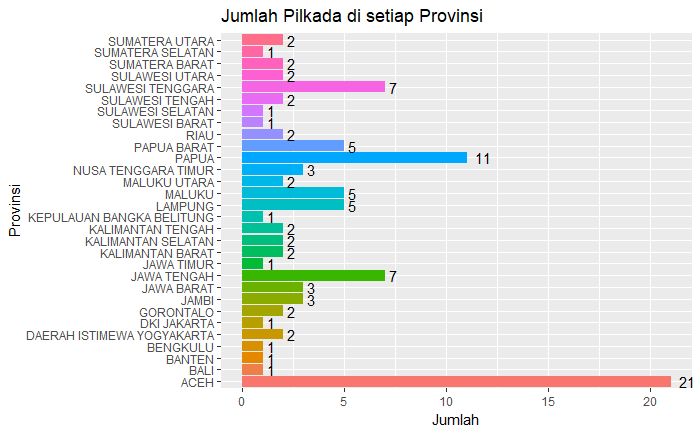

```r
ggplot(data=PW1, aes(x=namaPropinsi)) + geom_bar(aes(fill=namaPropinsi)) + coord_flip() + guides(fill=FALSE) + labs(title="Jumlah Pilkada di setiap Provinsi", x="Provinsi", y="Jumlah") + geom_text(aes(label = ..count..), stat = "count", hjust = -0.5)
```

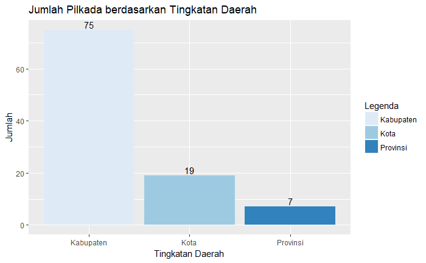

```r
ggplot(data=PW1, aes(x=Kategori)) + geom_bar(aes(fill=Kategori)) + scale_fill_brewer(palette="Blues", name="Legenda") + labs(title="Jumlah Pilkada berdasarkan Tingkatan Daerah", x="Tingkatan Daerah", y="Jumlah") + geom_text(aes(label = ..count..), stat = "count", vjust = -0.25)
```

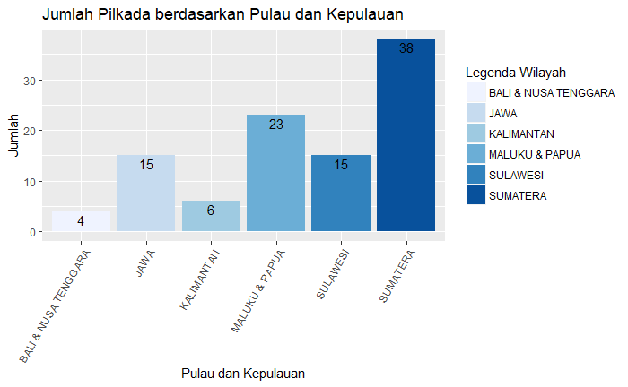

```r
ggplot(data=PW1, aes(x=namaPulauKepulauan)) + geom_bar(aes(fill=namaPulauKepulauan)) + scale_fill_brewer(palette="Blues", name="Legenda Wilayah") + labs(title="Jumlah Pilkada berdasarkan Pulau dan Kepulauan", x="Pulau dan Kepulauan", y="Jumlah") + geom_text(aes(label = ..count..), stat = "count", vjust = 1.25) + theme(axis.text.x = element_text(angle=60, hjust=1))
```

Rangkuman dari visualisasi di atas: 1. Jumlah Pilkada yang terjadi pada masing-masing Provinsi. Didapatkan total sejumlah 30 provinsi yang mengadakan pilkada secara serentak, baik pilkada setingkat Kabupaten, Kota, maupun Provinsi tersebut. Total pilkada yang tercatat adalah sejumlah 101 (sesuai dengan jumlah baris pada dataset ke-3). 2. Jumlah Pilkada yang terjadi berdasarkan Tingkatan Daerah Hal ini dapat dilihat pada grafik bahwa terdapat sejumlah 75 kabupaten yang mengikuti pilkada secara serentak pada tahun 2017, diikuti dengan 19 kota, dan terakhir 7 provinsi. 3. Jumlah Pilkada yang terjadai berdasarkan wilayah pulau & kepulauan Dari grafik tersebut dapat dilihat bahwa sangat banyak sekali pilkada yang terjadi di pulau Sumatera, diikuti dengan Kepulauan Maluku dan Papua, lalu Pulau Jawa dan Pulau Sulawesi (yang bernilai sama), diikuti pulau Kalimantan, dan terakhir kepulauan Bali dan Nusa Tenggara.

Kemudian, dilakukan visualisasi berikut: 1. Jumlah Suara pada Pilkada Tingkat Provinsi 2. Jumlah Suara pada Pilkada Tingkat Kabupaten (per Provinsi) 3. Jumlah Suara pada Pilkada Tingkat Kota (per Provinsi)

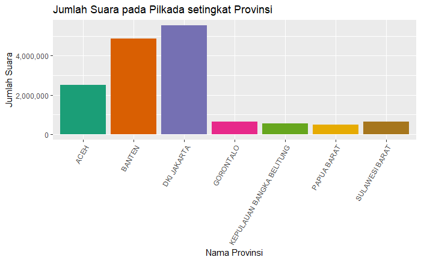

```r
ggplot(data=PW1[PW1$Kategori=="Provinsi",], aes(x=namaPropinsi, y=jumlahSuara)) + geom_bar(stat="identity", aes(fill=namaPropinsi)) + labs(title="Jumlah Suara pada Pilkada setingkat Provinsi", x="Nama Provinsi", y="Jumlah Suara") + theme(axis.text.x = element_text(angle=60, hjust=1), legend.position="none") + scale_y_continuous(labels=comma) + scale_fill_brewer(palette="Dark2")
```

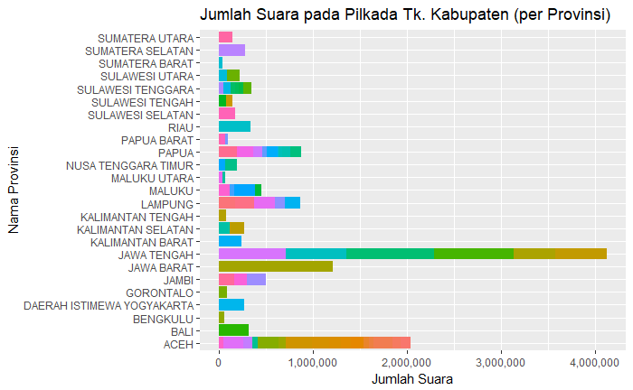

```r
ggplot(data=PW1[PW1$Kategori=="Kabupaten",], aes(x=namaPropinsi, y=jumlahSuara)) + geom_bar(stat="identity", aes(fill=namaWilayah)) + coord_flip() + labs(title="Jumlah Suara pada Pilkada Tk. Kabupaten (per Provinsi)", x="Nama Provinsi", y="Jumlah Suara") + theme(legend.position="none") + scale_y_continuous(labels=comma)
```

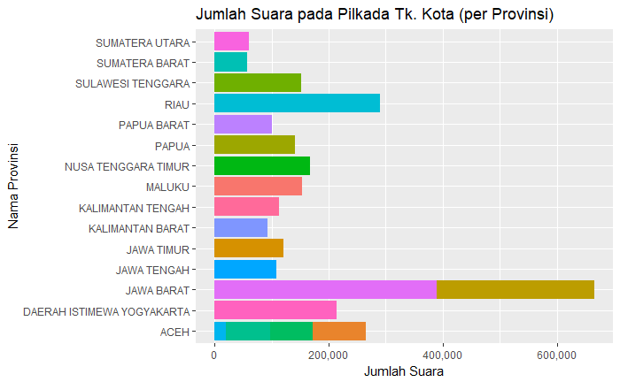

```r
ggplot(data=PW1[PW1$Kategori=="Kota",], aes(x=namaPropinsi, y=jumlahSuara)) + geom_bar(stat="identity", aes(fill=namaWilayah)) + coord_flip() + labs(title="Jumlah Suara pada Pilkada Tk. Kota (per Provinsi)", x="Nama Provinsi", y="Jumlah Suara") + theme(legend.position="none") + scale_y_continuous(labels=comma)
```

Kemudian, dilakukan pemetaan secara visual pada:

1. Jumlah Suara terhadap Jumlah TPS pada masing-masing Pilkada setingkat Provinsi
2. Jumlah Suara terhadap Jumlah TPS pada masing-masing Pilkada setingkat Kabupaten (berdasarkan Pulau dan Kepulauan)
3. Jumlah Suara terhadap Jumlah TPS pada masing-masing Pilkada setingkat Kota (berdasarkan Pulau dan Kepulauan)

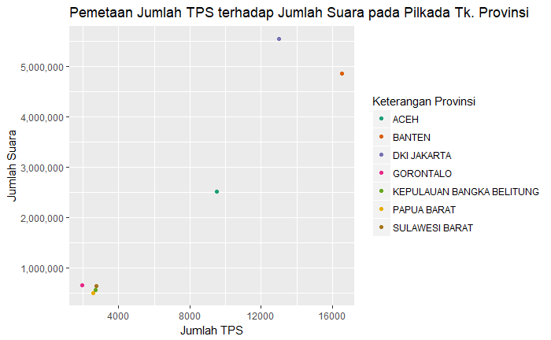

```r
ggplot(data=PW1[PW1$Kategori=="Provinsi",], aes(x=jumlahTps, y=jumlahSuara)) + geom_jitter(aes(colour=namaPropinsi)) + labs(title="Pemetaan Jumlah TPS terhadap Jumlah Suara pada Pilkada Tk. Provinsi", x="Jumlah TPS", y="Jumlah Suara") + scale_color_brewer(name= "Keterangan Provinsi", palette="Dark2") + scale_y_continuous(labels=comma)
```

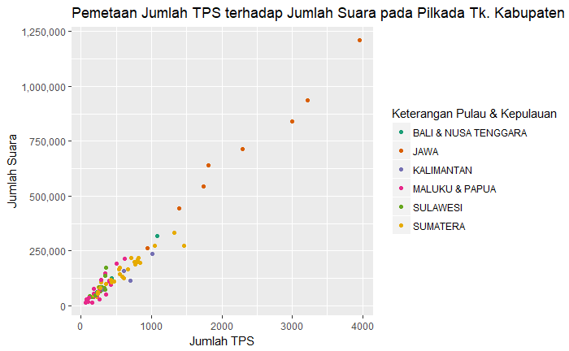

```r
ggplot(data=PW1[PW1$Kategori=="Kabupaten",], aes(x=jumlahTps, y=jumlahSuara)) + geom_jitter(aes(colour=namaPulauKepulauan)) + labs(title="Pemetaan Jumlah TPS terhadap Jumlah Suara pada Pilkada Tk. Kabupaten", x="Jumlah TPS", y="Jumlah Suara") + scale_color_brewer(name= "Keterangan Pulau & Kepulauan", palette="Dark2") + scale_y_continuous(labels=comma)
```

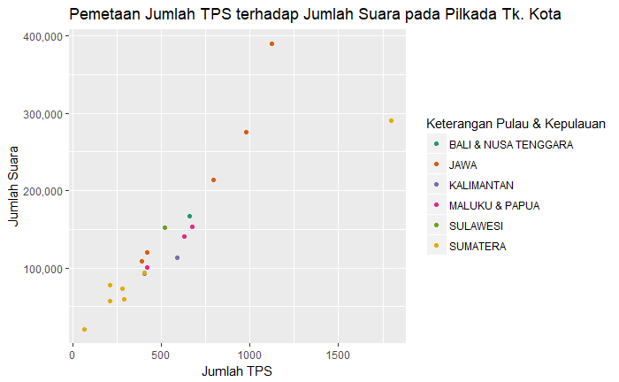

```r
ggplot(data=PW1[PW1$Kategori=="Kota",], aes(x=jumlahTps, y=jumlahSuara)) + geom_jitter(aes(colour=namaPulauKepulauan)) + labs(title="Pemetaan Jumlah TPS terhadap Jumlah Suara pada Pilkada Tk. Kota", x="Jumlah TPS", y="Jumlah Suara") + scale_color_brewer(name= "Keterangan Pulau & Kepulauan", palette="Dark2") + scale_y_continuous(labels=comma)
```

# 5 Transformasi Data : Pemetaan Paslon untuk mencari Paslon Tunggal atau Majemuk

Pertama-tama dilakukan transformasi terhadap data terlebih dahulu

```r
Paslon2017 <- PC1 %>%
  group_by(idWilayah, namaPemilihan, namaWilayah, namaPropinsi, namaKabupatenKota, Kategori, namaPulauKepulauan) %>%
  summarise(jumlahPaslon=n(), totalSuara=sum(jumlahSuara))
Paslon2017 <- as.data.frame(Paslon2017)
Paslon2017$jumlahPaslon <- as.factor(Paslon2017$jumlahPaslon)
str(Paslon2017)
```

```
'data.frame':   93 obs. of  9 variables:
 $ idWilayah         : Factor w/ 93 levels "1","269","671",..: 1 2 3 4 5 6 7 8 9 10 ...
 $ namaPemilihan     : Factor w/ 93 levels "Pemilihan Bupati/Walikota dan Wakil Bupati/Walikota - ACEH BARAT",..: 87 8 9 7 1 3 73 10 80 5 ...
 $ namaWilayah       : Factor w/ 93 levels "ACEH","ACEH BARAT",..: 1 9 10 8 2 4 78 11 86 6 ...
 $ namaPropinsi      : Factor w/ 30 levels "ACEH","BALI",..: 1 1 1 1 1 1 1 1 1 1 ...
 $ namaKabupatenKota : Factor w/ 86 levels "ACEH BARAT","ACEH BARAT DAYA",..: NA 8 9 7 1 3 73 10 80 5 ...
 $ Kategori          : Factor w/ 3 levels "Kabupaten","Kota",..: 3 1 1 1 1 1 1 1 1 1 ...
 $ namaPulauKepulauan: Factor w/ 6 levels "BALI & NUSA TENGGARA",..: 6 6 6 6 6 6 6 6 6 6 ...
 $ jumlahPaslon      : Factor w/ 8 levels "1","2","3","4",..: 6 2 2 6 3 2 3 4 3 4 ...
 $ totalSuara        : int  2397102 118249 181893 106472 104952 192784 199580 259117 47333 60528 ...
```

```r
summary(Paslon2017)
```

```
   idWilayah
 1      : 1
 269    : 1
 671    : 1
 1207   : 1
 1492   : 1
 1824   : 1
 (Other):87
                                                               namaPemilihan
 Pemilihan Bupati/Walikota dan Wakil Bupati/Walikota - ACEH BARAT     : 1
 Pemilihan Bupati/Walikota dan Wakil Bupati/Walikota - ACEH BARAT DAYA: 1
 Pemilihan Bupati/Walikota dan Wakil Bupati/Walikota - ACEH BESAR     : 1
 Pemilihan Bupati/Walikota dan Wakil Bupati/Walikota - ACEH JAYA      : 1
 Pemilihan Bupati/Walikota dan Wakil Bupati/Walikota - ACEH SINGKIL   : 1
 Pemilihan Bupati/Walikota dan Wakil Bupati/Walikota - ACEH TAMIANG   : 1
 (Other)                                                              :87
          namaWilayah            namaPropinsi       namaKabupatenKota      Kategori
 ACEH           : 1   ACEH             :21    ACEH BARAT     : 1      Kabupaten:69
 ACEH BARAT     : 1   PAPUA            :11    ACEH BARAT DAYA: 1      Kota     :17
 ACEH BARAT DAYA: 1   JAWA TENGAH      : 6    ACEH BESAR     : 1      Provinsi : 7
 ACEH BESAR     : 1   SULAWESI TENGGARA: 6    ACEH JAYA      : 1
 ACEH JAYA      : 1   LAMPUNG          : 4    ACEH SINGKIL   : 1
 ACEH SINGKIL   : 1   MALUKU           : 4    (Other)        :81
 (Other)        :87   (Other)          :41    NA's           : 7
            namaPulauKepulauan  jumlahPaslon   totalSuara
 BALI & NUSA TENGGARA: 4       2      :34    Min.   :  13342
 JAWA                :14       3      :26    1st Qu.:  70949
 KALIMANTAN          : 5       4      :16    Median : 115996
 MALUKU & PAPUA      :20       5      : 9    Mean   : 312716
 SULAWESI            :14       6      : 5    3rd Qu.: 199580
 SUMATERA            :36       1      : 1    Max.   :5487776
                               (Other): 2
```

Transformasi tersebut dilakukan untuk mencari tahu berapa banyak jumlah pilkada yang dilakukan jika dilihat dari jumlah pasangan calon yang mengikuti ajang tersebut.

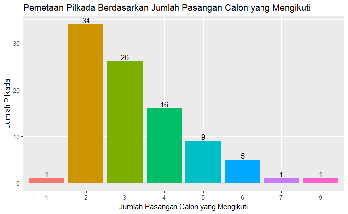

```r
ggplot(data=Paslon2017, aes(x=jumlahPaslon)) + geom_bar(aes(fill=jumlahPaslon)) + labs(title="Pemetaan Pilkada Berdasarkan Jumlah Pasangan Calon yang Mengikuti", x="Jumlah Pasangan Calon yang Mengikuti", y="Jumlah Pilkada") + theme(legend.position="none") + geom_text(aes(label=..count..), stat="Count", vjust=-0.25)
```

# 6 Transformasi Data : Pemetaan Kemenangan Paslon

Transformasi ketiga yang dilakukan:

```r
PC1a <- PC1
PC1a$hasilPaslon <- NA
for (i in 1:nrow(PC1a)){
     for (j in 1:nrow(Paslon2017)){
         if (PC1a$idWilayah[i]==Paslon2017$idWilayah[j]){
             PC1a$proporsi[i]=PC1a$jumlahSuara[i]/Paslon2017$totalSuara[j]
             PC1a$persentase[i]=paste0(round(PC1a$proporsi[i]*100,3), "%")
             if (PC1a$proporsi[i]>0.5) {
                   PC1a$hasilPaslon[i]="Suara didapat 50% < .."
               } else if ((PC1a$proporsi[i]>0.33) && (PC1a$proporsi[i]<=0.5)) {
                   PC1a$hasilPaslon[i]="Suara didapat 33% < ... <= 50%"
               } else if ((PC1a$proporsi[i]>0.25) && (PC1a$proporsi[i]<=0.33)) {
                   PC1a$hasilPaslon[i]="Suara didapat 25% < ... <= 33%"
               } else if ((PC1a$proporsi[i]>0.10) && (PC1a$proporsi[i]<=0.25)) {
                   PC1a$hasilPaslon[i]="Suara didapat 10% < ... <= 25%"
               } else {PC1a$hasilPaslon[i]="Suara didapat 10% >= ..."}
         }
      }
}
str(PC1a)
```

```
'data.frame':   302 obs. of  14 variables:
 $ idWilayah         : Factor w/ 93 levels "1","269","671",..: 1 1 1 1 1 1 5 5 5 12 ...
 $ nomorUrut         : Factor w/ 10 levels "1","2","3","4",..: 1 2 3 4 5 6 1 2 3 1 ...
 $ jumlahSuara       : int  403818 132439 42036 165979 762279 890551 48201 52538 4213 28138 ...
 $ namaPemilihan     : Factor w/ 93 levels "Pemilihan Bupati/Walikota dan Wakil Bupati/Walikota - ACEH BARAT",..: 87 87 87 87 87 87 1 1 1 2 ...
 $ namaWilayah       : Factor w/ 93 levels "ACEH","ACEH BARAT",..: 1 1 1 1 1 1 2 2 2 3 ...
 $ namaPropinsi      : Factor w/ 30 levels "ACEH","BALI",..: 1 1 1 1 1 1 1 1 1 1 ...
 $ namaKd            : Factor w/ 302 levels "A.S. Burhan, S.Ag",..: 208 299 64 61 152 73 43 154 124 15 ...
 $ namaWkd           : Factor w/ 302 levels "ABD. RAHIM ODEYANI, S.H., M.H.",..: 181 180 260 177 183 178 125 72 66 230 ...
 $ namaKabupatenKota : Factor w/ 86 levels "ACEH BARAT","ACEH BARAT DAYA",..: NA NA NA NA NA NA 1 1 1 2 ...
 $ Kategori          : Factor w/ 3 levels "Kabupaten","Kota",..: 3 3 3 3 3 3 1 1 1 1 ...
 $ namaPulauKepulauan: Factor w/ 6 levels "BALI & NUSA TENGGARA",..: 6 6 6 6 6 6 6 6 6 6 ...
 $ hasilPaslon       : chr  "Suara didapat 10% < ... <= 25%" "Suara didapat 10% >= ..." "Suara didapat 10% >= ..." "Suara didapat 10% >= ..." ...
 $ proporsi          : num  0.1685 0.0552 0.0175 0.0692 0.318 ...
 $ persentase        : chr  "16.846%" "5.525%" "1.754%" "6.924%" ...
```

```r
summary(PC1a)
```

```
   idWilayah     nomorUrut   jumlahSuara
 4989   :  9   1      :92   Min.   :    103
 5920   :  7   2      :92   1st Qu.:  13914
 1      :  6   3      :59   Median :  31815
 1207   :  6   4      :31   Mean   :  96300
 4362   :  6   5      :16   3rd Qu.:  77005
 56244  :  6   6      : 7   Max.   :2406132
 (Other):262   (Other): 5
                                                               namaPemilihan
 Pemilihan Bupati/Walikota dan Wakil Bupati/Walikota - ACEH BARAT DAYA:  9
 Pemilihan Bupati/Walikota dan Wakil Bupati/Walikota - BENER MERIAH   :  7
 Pemilihan Bupati/Walikota dan Wakil Bupati/Walikota - ACEH TENGAH    :  6
 Pemilihan Bupati/Walikota dan Wakil Bupati/Walikota - BIREUEN        :  6
 Pemilihan Bupati/Walikota dan Wakil Bupati/Walikota - FLORES TIMUR   :  6
 Pemilihan Bupati/Walikota dan Wakil Bupati/Walikota - KEPULAUAN YAPEN:  6
 (Other)                                                              :262
          namaWilayah               namaPropinsi                namaKd
 ACEH BARAT DAYA:  9   ACEH               : 86   A.S. Burhan, S.Ag :  1
 BENER MERIAH   :  7   PAPUA              : 39   Abdul Majid, S.Psi:  1
 ACEH           :  6   JAWA TENGAH        : 16   ABDUL MANSUR AMILA:  1
 ACEH TENGAH    :  6   SULAWESI TENGGARA  : 16   Abdul Rasak, S.P. :  1
 BIREUEN        :  6   NUSA TENGGARA TIMUR: 13   ABUN YANI, SH     :  1
 FLORES TIMUR   :  6   JAWA BARAT         : 11   ADAM, SE          :  1
 (Other)        :262   (Other)            :121   (Other)           :296
                           namaWkd          namaKabupatenKota      Kategori
 ABD. RAHIM ODEYANI, S.H., M.H.:  1   ACEH BARAT DAYA:  9     Kabupaten:225
 ABDU RANI,S.Sos               :  1   BENER MERIAH   :  7     Kota     : 53
 ABDUL KHOLIK, SE, M.Si        :  1   ACEH TENGAH    :  6     Provinsi : 24
 ABDUL MANAF                   :  1   BIREUEN        :  6
 Abdul Rani                    :  1   FLORES TIMUR   :  6
 ABDULLAH MANARAY, ST          :  1   (Other)        :244
 (Other)                       :296   NA's           : 24
            namaPulauKepulauan hasilPaslon           proporsi
 BALI & NUSA TENGGARA: 15      Length:302         Min.   :0.006302
 JAWA                : 40      Class :character   1st Qu.:0.157708
 KALIMANTAN          : 16      Mode  :character   Median :0.314782
 MALUKU & PAPUA      : 62                         Mean   :0.307947
 SULAWESI            : 37                         3rd Qu.:0.451200
 SUMATERA            :132                         Max.   :1.000000

  persentase
 Length:302
 Class :character
 Mode  :character
```

```r
Pemenang2017 <- PC1a %>%
  group_by(idWilayah, namaPemilihan, namaWilayah, namaPropinsi, namaKabupatenKota, Kategori, namaPulauKepulauan) %>%
  summarise(hasilpemenang=max(proporsi), jumlahPaslonTerdaftar=max(as.numeric(nomorUrut)), totalSuara=sum(jumlahSuara))
Pemenang2017 <- as.data.frame(Pemenang2017)
str(Pemenang2017)
```

```
'data.frame':   93 obs. of  10 variables:
 $ idWilayah            : Factor w/ 93 levels "1","269","671",..: 1 2 3 4 5 6 7 8 9 10 ...
 $ namaPemilihan        : Factor w/ 93 levels "Pemilihan Bupati/Walikota dan Wakil Bupati/Walikota - ACEH BARAT",..: 87 8 9 7 1 3 73 10 80 5 ...
 $ namaWilayah          : Factor w/ 93 levels "ACEH","ACEH BARAT",..: 1 9 10 8 2 4 78 11 86 6 ...
 $ namaPropinsi         : Factor w/ 30 levels "ACEH","BALI",..: 1 1 1 1 1 1 1 1 1 1 ...
 $ namaKabupatenKota    : Factor w/ 86 levels "ACEH BARAT","ACEH BARAT DAYA",..: NA 8 9 7 1 3 73 10 80 5 ...
 $ Kategori             : Factor w/ 3 levels "Kabupaten","Kota",..: 3 1 1 1 1 1 1 1 1 1 ...
 $ namaPulauKepulauan   : Factor w/ 6 levels "BALI & NUSA TENGGARA",..: 6 6 6 6 6 6 6 6 6 6 ...
 $ hasilpemenang        : num  0.372 0.532 0.513 0.305 0.501 ...
 $ jumlahPaslonTerdaftar: num  6 2 2 6 3 2 3 4 3 4 ...
 $ totalSuara           : int  2397102 118249 181893 106472 104952 192784 199580 259117 47333 60528 ...
```

```r
Pemenang2017$jumlahPaslonTerdaftar <- as.factor(Pemenang2017$jumlahPaslonTerdaftar)
Pemenang2017$nomorUrutPemenang <- NA
Pemenang2017$namaKdPemenang <- NA
Pemenang2017$namaWKdPemenang <- NA
Pemenang2017$hasil <- NA
for (i in 1:nrow(Pemenang2017)){
   for (j in 1:nrow(PC1a)){
       if (PC1a$proporsi[j]==Pemenang2017$hasilpemenang[i]){
           Pemenang2017$nomorUrutPemenang[i]=PC1a$nomorUrut[j]
           Pemenang2017$namaKdPemenang[i]=as.character(PC1a$namaKd[j])
           Pemenang2017$namaWKdPemenang[i]=as.character(PC1a$namaWkd[j])
           Pemenang2017$hasil[i]=as.character(PC1a$hasilPaslon[j])
       }
   }
}
Pemenang2017$nomorUrutPemenang <- as.factor(Pemenang2017$nomorUrutPemenang)
```

```r
summary(Pemenang2017)
```

```
   idWilayah
 1      : 1
 269    : 1
 671    : 1
 1207   : 1
 1492   : 1
 1824   : 1
 (Other):87
                                                               namaPemilihan
 Pemilihan Bupati/Walikota dan Wakil Bupati/Walikota - ACEH BARAT     : 1
 Pemilihan Bupati/Walikota dan Wakil Bupati/Walikota - ACEH BARAT DAYA: 1
 Pemilihan Bupati/Walikota dan Wakil Bupati/Walikota - ACEH BESAR     : 1
 Pemilihan Bupati/Walikota dan Wakil Bupati/Walikota - ACEH JAYA      : 1
 Pemilihan Bupati/Walikota dan Wakil Bupati/Walikota - ACEH SINGKIL   : 1
 Pemilihan Bupati/Walikota dan Wakil Bupati/Walikota - ACEH TAMIANG   : 1
 (Other)                                                              :87
          namaWilayah            namaPropinsi       namaKabupatenKota      Kategori
 ACEH           : 1   ACEH             :21    ACEH BARAT     : 1      Kabupaten:69
 ACEH BARAT     : 1   PAPUA            :11    ACEH BARAT DAYA: 1      Kota     :17
 ACEH BARAT DAYA: 1   JAWA TENGAH      : 6    ACEH BESAR     : 1      Provinsi : 7
 ACEH BESAR     : 1   SULAWESI TENGGARA: 6    ACEH JAYA      : 1
 ACEH JAYA      : 1   LAMPUNG          : 4    ACEH SINGKIL   : 1
 ACEH SINGKIL   : 1   MALUKU           : 4    (Other)        :81
 (Other)        :87   (Other)          :41    NA's           : 7
            namaPulauKepulauan hasilpemenang    jumlahPaslonTerdaftar
 BALI & NUSA TENGGARA: 4       Min.   :0.2706   2      :33
 JAWA                :14       1st Qu.:0.4099   3      :27
 KALIMANTAN          : 5       Median :0.4974   4      :16
 MALUKU & PAPUA      :20       Mean   :0.4994   5      : 9
 SULAWESI            :14       3rd Qu.:0.5539   6      : 5
 SUMATERA            :36       Max.   :1.0000   1      : 1
                                                (Other): 2
   totalSuara      nomorUrutPemenang namaKdPemenang     namaWKdPemenang
 Min.   :  13342   1:27              Length:93          Length:93
 1st Qu.:  70949   2:35              Class :character   Class :character
 Median : 115996   3:20              Mode  :character   Mode  :character
 Mean   : 312716   4: 4
 3rd Qu.: 199580   5: 4
 Max.   :5487776   6: 3

    hasil
 Length:93
 Class :character
 Mode  :character
```

Transformasi tersebut dilakukan untuk mencari tahu berapa nomor urut yang paling favorit.

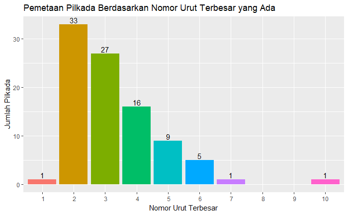

```r
ggplot(data=Pemenang2017, aes(x=jumlahPaslonTerdaftar)) + geom_bar(aes(fill=jumlahPaslonTerdaftar)) + scale_x_discrete(limits=c(1, 2, 3, 4, 5, 6, 7, 8, 9, 10)) + labs(title="Pemetaan Pilkada Berdasarkan Nomor Urut Terbesar yang Ada", x="Nomor Urut Terbesar", y="Jumlah Pilkada") + theme(legend.position="none") + geom_text(aes(label=..count..), stat="count", vjust=-0.25)
```

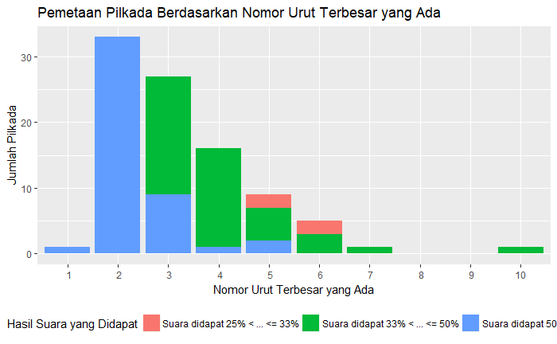

```r
ggplot(data=Pemenang2017, aes(x=jumlahPaslonTerdaftar)) + geom_bar(aes(fill=hasil)) + scale_x_discrete(limits=c(1, 2, 3, 4, 5, 6, 7, 8, 9, 10)) + labs(title="Pemetaan Pilkada Berdasarkan Nomor Urut Terbesar yang Ada", x="Nomor Urut Terbesar yang Ada", y="Jumlah Pilkada") + theme(legend.position="bottom") + scale_fill_discrete(name="Hasil Suara yang Didapat")
```

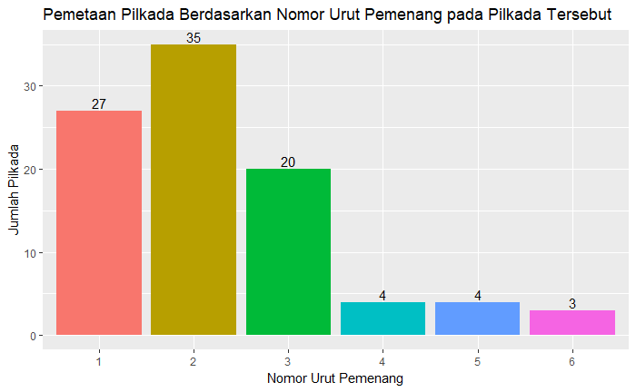

```r
ggplot(data=Pemenang2017, aes(x=nomorUrutPemenang)) + geom_bar(aes(fill=nomorUrutPemenang)) + scale_x_discrete(limits=c(1, 2, 3, 4, 5, 6)) + labs(title="Pemetaan Pilkada Berdasarkan Nomor Urut Pemenang pada Pilkada Tersebut", x="Nomor Urut Pemenang", y="Jumlah Pilkada") + theme(legend.position="none") + geom_text(aes(label=..count..), stat="count", vjust=-0.25) + scale_fill_discrete(name="Hasil Suara yang Didapat")
```

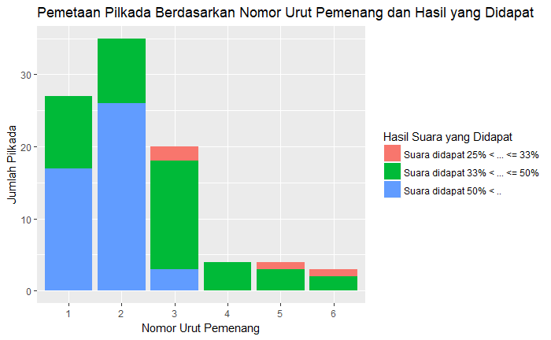

```r
ggplot(data=Pemenang2017, aes(x=nomorUrutPemenang)) + geom_bar(aes(fill=hasil)) + scale_x_discrete(limits=c(1, 2, 3, 4, 5, 6)) + labs(title="Pemetaan Pilkada Berdasarkan Nomor Urut Pemenang dan Hasil yang Didapat", x="Nomor Urut Pemenang", y="Jumlah Pilkada") + scale_fill_discrete(name="Hasil Suara yang Didapat")
```